# Chapter 7: Hypothesis Testing

# Survey

Final survey data is available. You can load it by running the code below:

```r
 survey <-readRDS(url('https://github.com/Neilblund/GVPT-201-Site/raw/refs/heads/main/Rdata/survey_fmted.rds'))
```

You can read the codebook at [this link](https://neilblund.github.io/GVPT-201-Site/final_survey_codebook.html).

Or download the entire questionnaire from ELMS at [this link](https://umd.instructure.com/files/83271984/download?download_frd=1). (Also in the files section in the “Survey data” folder.)

# Testing a hypothesis

- Last week we talked about ways to determine the probability of some an error of a given size and identify a confidence interval around an estimate
- This week: hypothesis testing

## Testing a hypothesis

- In hypothesis testing, we’re still basically concerned with quantifying error, but we want to know the probability that an error produced some difference or estimated effect of X on Y.

## Testing a hypothesis

Imagine:

I’ve got a hypothesis that democracies will have more protests than autocratic states. Here are my initial results:

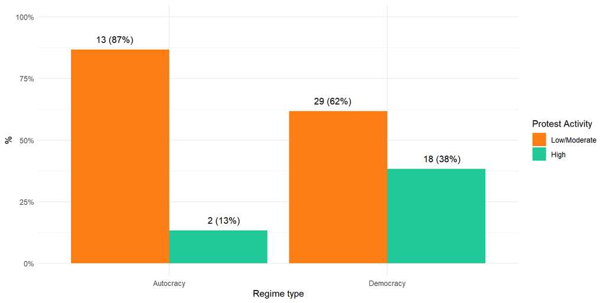

| Level of protest activity | Autocracy | Democracy |
| --- | --- | --- |
| Low/Moderate | 13 (87%) | 29 (62%) |
| High | 2 (13%) | 18 (38%) |

## Testing a hypothesis

- Of course, its possible that there’s a real relationship here, but its also possible to produce disparities this large just by random chance.
- Hypothesis testing answers the question: “how likely is it that we would see results like these due to randomness?”

| Level of protest activity | Autocracy | Democracy |
| --- | --- | --- |
| Low/Moderate | 13 (87%) | 29 (62%) |
| High | 2 (13%) | 18 (38%) |

## Null vs. Alternative Hypothesis

There are really two “sides” of our hypothesis:

*Alternative/Research hypothesis* ($H_a$): “X and Y are related”, “X influences Y”, or “this outcome is not random”

*Null hypothesis* $H_0$: “no relationship”, “no effect” or “no better than random chance”

Technically, we don’t really test $H_a$. Instead we’ll try to rule out $H_0$ by asking “how likely is it that random chance would give us results like these?”.

## Type I and II error

When trying to make a judgement about $H_0$, there are two ways to be wrong:

- Type I errors: we think X and Y are related, but the result is actually random. Incorrectly rejecting the null (False positive)
- Type II errors: X and Y are actually related, but we fail to spot it. Incorrectly failing to reject the null (False negative)

|  | X and Y actually are related | X and Y are unrelated |
| --- | --- | --- |
| Test is significant | Correct | Type I error |
| Test is not significant | Type II error | Correct |

In general, we’re more concerned with Type I error, so we put a relatively high burden of evidence for showing things are related, even if that means we’ll sometimes get false negatives.

## What hypothesis testing won’t do

- Hypothesis testing won’t tell us “there’s 0% chance that randomness produced this result”. There’s always *some* possibility that random error produced something.
- It also doesn’t tell us whether we have a spurious correlation or a biased sample.
- It won’t tell us the probability of any hypothesis. It only tells us the probability of a result if a hypothesis is true.

# Testing a hypothesis with p-values

## The P-value method

P-values are one of two ways that we can determine whether to reject the null hypothesis

(we’ll talk about the other method, confidence intervals, in the next class)

### The P-value method

**P-value**

A p-value represents the probability of seeing a test statistic that is less than or equal to, greater than or equal to, or absolutely greater than than the one you see in your sample if the null hypothesis is true.

A test statistic is a single value that summarizes the relationship between X and Y. It will be different depending on the test you’re using.

Sometimes we have a hypothesis about the direction of the relationship, but not always. This will influence how we calculate P.

A P-value always represents the probability of the result under the null, this isn’t the same as the probability of a hypothesis (although this a common misconception)

## Hypothesis testing: general steps for P-values

1. State $H_0$ and $H_a$
2. Decide on threshold for significance, sometimes called $\alpha$.
   1. (.1, .05, and .01 are common thresholds.)
3. Run the test and calculate a p-value.
   1. $p \geq \alpha$ means the result is not statistically significant at your threshold. You fail to reject the null.
   2. A $p \leq \alpha$ means the result is statistically significant. You can reject the null.

Note that smaller is better! We want p to be as low as possible because it means “its unlikely that this is caused by random chance”.

## An experimental hypothesis test

Can our subject distinguish tap water from bottled?

- Alternative hypothesis ($H_a$): the subject can reliably identify bottled water and tap water.
- Null hypothesis ($H_0$): the subject is guessing

## The Lady Tasting Tea

R.A Fisher lays out an experiment along these lines in a 1935 book.

(in that case, it was a psychologist who said she could tell whether a cup of tea was poured milk-first or tea-first)

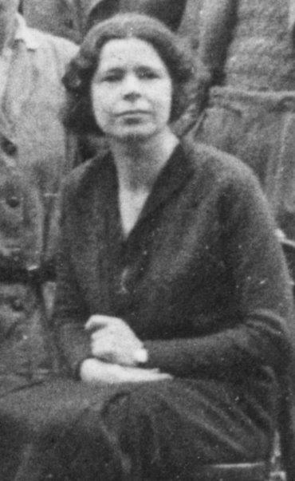

Muriel Bristol-Roach

## Our experiment

Experimental Setup:

- 8 glasses of water.
- 4 are tap water 🚰, and 4 are bottled 💧
  - the subject knows how many of each, but not which is which
- The subject tastes all 8 and categorizes them, then the researcher counts the number of correct vs. incorrect.

## Our hypothesis test

Our p-value here will be calculated based on the number of cups correctly classified as tap or bottled.

So:

## Fisher’s Exact Test

💧1

💧2

💧3

💧4

🚰5

🚰6

🚰7

🚰8

Fisher’s proposed test is non-parametric, it doesn’t require any assumptions about distributions or infinity or repeated sampling. Instead, we’re going to calculate an exact probability based on counting all the ways a random guess could generate different outcomes. We’ll need to calculate:

- The number of ways to choose 0, 1, 2, 3, or 4 cups correctly
- The total number of combinations of four cups.

### Combinations

How many ways are there to randomly get 4 out of 4 bottled waters correctly classified? (ignore the ordering)

💧1

💧2

💧3

💧4

🚰5

🚰6

🚰7

🚰8

Just 1:

💧1

💧2

💧3

💧4

### Combinations

How many ways are there to correctly classify 3 cups out of 4 by random chance?

💧1

💧2

💧3

💧4

🚰5

🚰6

🚰7

🚰8

### Combinations

How many ways are there to correctly classify 3 cups out of 4 by random chance?

💧1

💧2

💧3

💧4

🚰5

🚰6

🚰7

🚰8

💧2

💧3

💧4

### Combinations

How many ways are there to correctly classify 3 cups out of 4 by random chance?

💧1

💧2

💧3

💧4

🚰5

🚰6

🚰7

🚰8

💧2

💧3

💧4

💧1

💧3

💧4

### Combinations

How many ways are there to correctly classify 3 cups out of 4 by random chance?

💧1

💧2

💧3

💧4

🚰5

🚰6

🚰7

🚰8

💧2

💧3

💧4

💧2

💧3

💧4

💧1

💧2

💧4

### Combinations

How many ways are there to correctly classify 3 cups out of 4 by random chance?

💧1

💧2

💧3

💧4

🚰5

🚰6

🚰7

🚰8

💧2

💧3

💧4

💧2

💧3

💧4

💧1

💧2

💧4

💧1

💧2

💧3

Any of these could be paired up with any 1 tap water. So…

### Combinations

How many ways are there to correctly classify 3 cups out of 4 by random chance?

💧1

💧2

💧3

💧4

🚰5

🚰6

🚰7

🚰8

🚰5

💧2

💧3

💧4

💧1

🚰5

💧2

💧3

💧1

💧2

🚰5

💧4

💧1

💧2

💧3

🚰5

🚰6

💧2

💧3

💧4

💧1

🚰6

💧2

💧3

💧1

💧2

🚰6

💧4

💧1

💧2

💧3

🚰6

🚰7

💧2

💧3

💧4

💧1

🚰7

💧2

💧3

💧1

💧2

🚰7

💧4

💧1

💧2

💧3

🚰7

🚰8

💧2

💧3

💧4

💧1

🚰8

💧2

💧3

💧1

💧2

🚰8

💧4

💧1

💧2

💧3

🚰8

16 possible combinations to reach 3 out of 4 correct selections.

### Combinations

How many ways can you get 2 cups correct out of 4?

💧1

💧2

💧3

💧4

🚰5

🚰6

🚰7

🚰8

6 ways to choose two 💧  
[💧1, 💧2] [💧1, 💧3] [💧1, 💧4] [💧2, 💧3] [💧2, 💧4] [💧3, 💧4]

X

6 ways to choose two 🚰  
[🚰5, 🚰6] [🚰5, 🚰7] [🚰5, 🚰8] [🚰6, 🚰7] [🚰6, 🚰8] [🚰7, 🚰8]

= 36 combinations

### Total combinations

There’s an equal number of 💧 and 🚰 here, so the probability of getting 3 correct is the same as the probability of getting 3 incorrect (same for other combos). So we’ve got everything we need:

| number correct | Total combos |
| --- | --- |
| 4 | 1 x 1 = 1 |
| 3 | 4 x 4 = 16 |
| 2 | 6 x 6 = 36 |
| 1 | 4 x 4 = 16 |
| 0 | 1 x 1 = 1 |

70 total possible combinations

### Total combinations

| number correct | Total combos | Pr(number correct) |
| --- | --- | --- |
| 4 | 1 x 1 = 1 | 1/70 = .014 |
| 3 | 4 x 4 = 16 | 16/70 = .23 |
| 2 | 6 x 6 = 36 | 36/70 = .51 |
| 1 | 4 x 4 = 16 | 16/70 = .23 |
| 0 | 1 x 1 = 1 | 1/70 = .014 |

The probability of exactly n correct is just number of combinations for n correct / total possible combinations.

### P-values from the exact test

But remember that our P-value is the probability of get **at least** as many correct by random chance, so:

[output not shown]

Our $\alpha$ was .05, so, in order for us to reject the null hypothesis, the subject needs to correctly group all four cups.

### Analyzing the results

Always state the p-value in terms of the null:

- if our observed p-value is greater than alpha, we fail to reject the null
- if our observed p-value is less than alpha, we reject the null
- note that 3 out 4 is still better than a guess! but we still fail to reject the null because of that “burden of evidence” idea: we care more about Type I error

### Two-tailed P-values

Our initial example used a “one-tailed” test. We asked “what’s the probability of getting at least this many correct”? But what if the subject got 0 out of 4 correct. Would this be meaningful?

- Maybe! We can re-state the hypothesis: “the subject can reliably distinguish tap water from bottled”. Always being wrong could still suggest something non-random.
- This is a kind of two-tailed test: we’re not concerned about the direction of the effect, just its absolute value.

### Two-tailed P-values

To calculate a two-tailed p-value, we can just calculate the probability of getting “at least K” correct OR incorrect:

[output not shown]

Our two-tailed hypothesis is less specific, so this penalty to the p-value is a fair tradeoff.

### Fisher’s Exact Test in general

Fisher’s Exact Test is a test of statistical significance for categorical relationships. Its most commonly used for small-sample experiments, but it can be used to test observational hypotheses as well.

### Fisher’s Exact Test in general

I hypothesized that democracies would have higher levels of protest activity.

But could this difference be attributable to random chance?

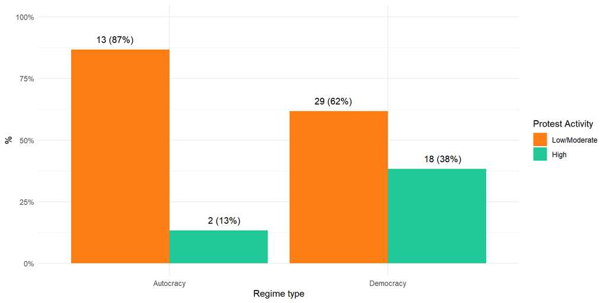

| Level of protest activity | Autocracy | Democracy |
| --- | --- | --- |
| Low/Moderate | 13 (87%) | 29 (62%) |
| High | 2 (13%) | 18 (38%) |

### Fisher’s Exact Test in general

|  | X0 | X1 |
| --- | --- | --- |
| **Y0** | a | b |
| **Y1** | c | d |

**Fisher’s Exact Test**

$$Pr(\text{of this table}) = \frac{(a+b)! (c+d)! (a+c)! (b + d)!}{a! b! c! d! n!}$$
(Not something you need to know for a test or homework!)

The $!$ is a factorial, so $4!$ means $4\times3\times2\times1$. For a two-tailed test, this would need to be calculated for every arrangement of cell counts where the disparity is at least this extreme (without changing the row or column totals)

Fortunately, we don’t need to do this ourselves.

### Fisher’s Exact Test in general

```r
# make a table
ctab<-table(world$protact2, world$vdem.2cat)


# test the table
fisher.test(ctab, alternative = "greater")$p.value
```

```
[1] 0.06452723
```

There is a 6% chance of generating a table with a discrepancy at least this large by random chance. So we can’t rule out the null here at conventional levels.

### Fisher’s Exact Test

- The biggest issue with Fisher’s exact test is that its slow and messy for big samples (think about calculating $1000$ factorial)
- So its generally more common to use $\chi^2$ (pronounced like “kai”) with decently large sample sizes.

## Next up

- We’ll talk about alternative ways for testing the significance of a crosstab: $\chi^2$, Somer’s D and Lambda
- We’ll return to the central limit theorem and Z/T values to talk about hypothesis testing for the difference in averages between two groups.